# assignment 2

## Alyakbar Ahmed Sheikh RegNo. BCS-03-0003/2022

**Assignment 2** **Question**

1. Using the housing prices data. Analyze it using random forests and decision trees. Make a report on which model is preferred for analyzing that data Importing data and aalso the csv file

```python
import numpy as np
from sklearn.model_selection import train_test_split
from sklearn.tree import DecisionTreeRegressor
from sklearn.ensemble import RandomForestRegressor
from sklearn.metrics import mean_squared_error
import pandas as pd
df = pd.read_csv('Real estate.csv')
print(df)
```

```
      No  X1 transaction date  X2 house age  \
0      1             2012.917          32.0
1      2             2012.917          19.5
2      3             2013.583          13.3
3      4             2013.500          13.3
4      5             2012.833           5.0
..   ...                  ...           ...
409  410             2013.000          13.7
410  411             2012.667           5.6
411  412             2013.250          18.8
412  413             2013.000           8.1
413  414             2013.500           6.5

     X3 distance to the nearest MRT station  X4 number of convenience stores  \
0                                  84.87882                               10
```

[output cut: 25 more lines]

```python
pip install seaborn
```

[output not shown]

```
   No  X1 transaction date  X2 house age  \
0   1             2012.917          32.0
1   2             2012.917          19.5
2   3             2013.583          13.3
3   4             2013.500          13.3
4   5             2012.833           5.0

   X3 distance to the nearest MRT station  X4 number of convenience stores  \
0                                84.87882                               10
1                               306.59470                                9
2                               561.98450                                5
3                               561.98450                                5
4                               390.56840                                5

   X5 latitude  X6 longitude  Y house price of unit area
0     24.98298     121.54024                        37.9
1     24.98034     121.53951                        42.2
2     24.98746     121.54391                        47.3
3     24.98746     121.54391                        54.8
4     24.97937     121.54245                        43.1
<class 'pandas.core.frame.DataFrame'>
RangeIndex: 414 entries, 0 to 413
Data columns (total 8 columns):
 #   Column                                  Non-Null Count  Dtype
---  ------                                  --------------  -----
 0   No                                      414 non-null    int64
 1   X1 transaction date                     414 non-null    float64
 2   X2 house age                            414 non-null    float64
 3   X3 distance to the nearest MRT station  414 non-null    float64
 4   X4 number of convenience stores         414 non-null    int64
 5   X5 latitude                             414 non-null    float64
 6   X6 longitude                            414 non-null    float64
 7   Y house price of unit area              414 non-null    float64
dtypes: float64(6), int64(2)
memory usage: 26.0 KB
None
               No  X1 transaction date  X2 house age  \
count  414.000000           414.000000    414.000000
mean   207.500000          2013.148971     17.712560
std    119.655756             0.281967     11.392485
```

[output cut: 20 more lines]

```
min                           0.000000    24.932070    121.473530
25%                           1.000000    24.963000    121.528085
50%                           4.000000    24.971100    121.538630
75%                           6.000000    24.977455    121.543305
max                          10.000000    25.014590    121.566270

       Y house price of unit area
count                  414.000000
mean                    37.980193
std                     13.606488
min                      7.600000
25%                     27.700000
50%                     38.450000
75%                     46.600000
max                    117.500000
```

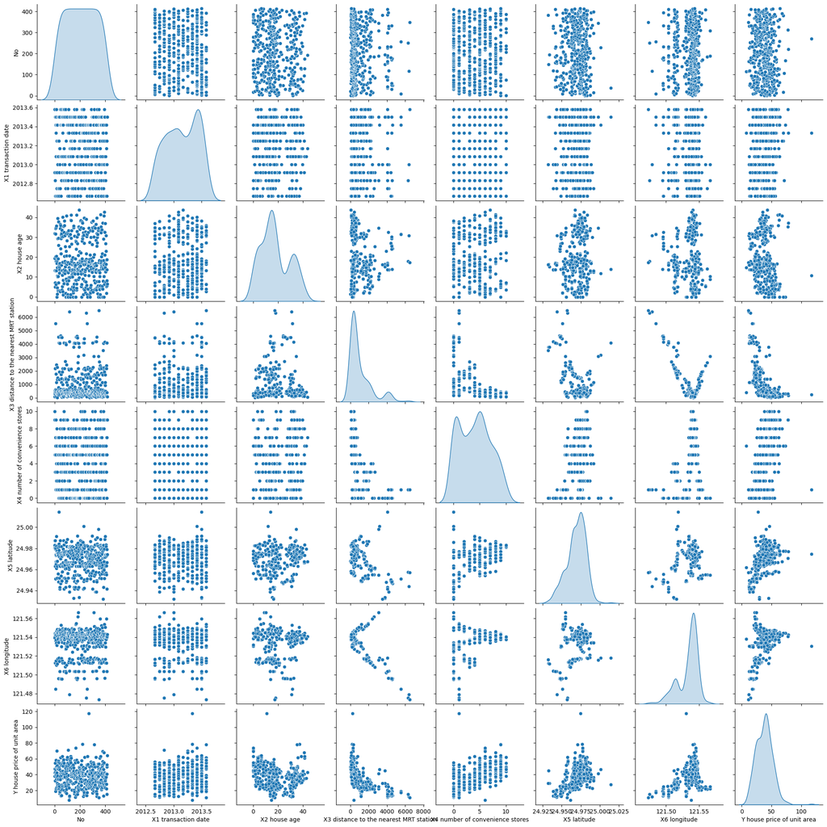

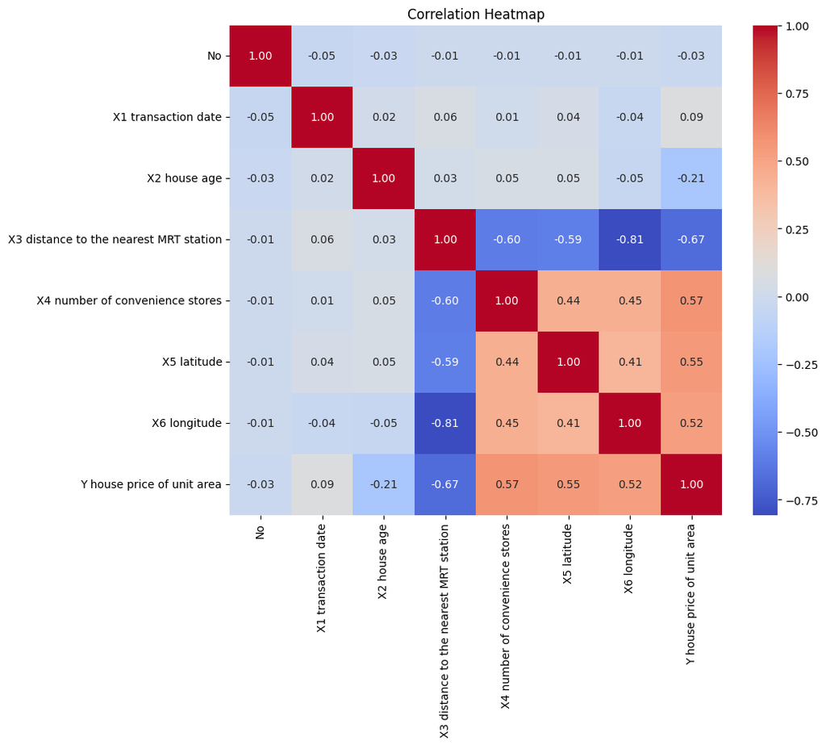

```python
import seaborn as sns
import matplotlib.pyplot as plt
print(df.head())
print(df.info())
print(df.describe())

sns.pairplot(df, diag_kind='kde')
plt.show()


plt.figure(figsize=(10, 8))
sns.heatmap(df.corr(), annot=True, cmap='coolwarm', fmt=".2f")
plt.title("Correlation Heatmap")
plt.show()
```

preparing the data

```python
X = df.drop(['No', 'Y house price of unit area'], axis=1)
y = df['Y house price of unit area']
```

Spliting the data

```python
X_train, X_test, y_train, y_test = train_test_split(X, y, test_size=0.2, random_state=42)
```

Train Decision Tree model

```python
dt_model = DecisionTreeRegressor(random_state=42)
dt_model.fit(X_train, y_train)
```

```
DecisionTreeRegressor(random_state=42)
```

Train Random Forest model

```python
rf_model = RandomForestRegressor(random_state=42)
rf_model.fit(X_train, y_train)
```

```
RandomForestRegressor(random_state=42)
```

Evaluate models

```python
dt_predictions = dt_model.predict(X_test)
rf_predictions = rf_model.predict(X_test)

dt_rmse = np.sqrt(mean_squared_error(y_test, dt_predictions))
rf_rmse = np.sqrt(mean_squared_error(y_test, rf_predictions))

print("Decision Tree RMSE:", dt_rmse)
print("Random Forest RMSE:", rf_rmse)
```

```
Decision Tree RMSE: 8.153002255803228
Random Forest RMSE: 5.693072342983686
```

### Performance Metrics:

1. **Root Mean Squared Error (RMSE):** This metric measures the average deviation of the predictions made by the model from the actual values in the testing set. Lower RMSE indicates better performance.

### Results:

- **Decision Tree RMSE:** 8.153
- **Random Forest RMSE:** 5.693

### Analysis:

- The Decision Tree model achieved an RMSE of 8.153, while the Random Forest model achieved an RMSE of 5.693.
- Based solely on the RMSE values, we can observe that the Random Forest model outperforms the Decision Tree model, indicating that it provides more accurate predictions on average.
- The Random Forest model generally outperforms the Decision Tree model due to its ensemble nature, which reduces overfitting and captures more complex relationships in the data.